# Modeling Solubility with DeepChem

This notebook shows how to use DeepChem to build a predictive model for aqueous solubility. It's based on one included in the [DeepChem source repository](https://github.com/deepchem/deepchem/blob/master/examples/tutorials/03_Modeling_Solubility.ipynb). The following steps are covered:

1. Obtain a solubility dataset.
2. Inspect the dataset structures and associated data.
3. Featurize molecules.
4. Split the dataset into training, validation, and testing subsets.
5. Train a random forest model.
6. Optimize the model hyperparameters.
7. Plot prediced vs. measured solubilities for the testing subset.

Begin by importing DeepChem and ensuring the correct version.

```python
import deepchem
deepchem.__version__
```

```
'2.4.0-rc1.dev'
```

## Dataset

We'll be using [an aqueous solubility dataset](https://raw.githubusercontent.com/deepchem/deepchem/master/datasets/delaney-processed.csv) adapated from [the paper by Delaney](https://doi.org/10.1021/ci034243x).

```python
%%capture
!wget https://raw.githubusercontent.com/deepchem/deepchem/master/datasets/delaney-processed.csv -O delaney-processed.csv
```

## Inspect

The next few steps will produce some simple visualizations of the data set. Only two colums will be used in this notebook:

- `smiles`
- `measured log solubility in mols per litre`

Printing column headings and row count yields a quick overview of what's contained in the data file.

```python
from deepchem.utils.save import load_from_disk

dataset_file= "delaney-processed.csv"
dataset = load_from_disk(dataset_file)
print("Columns: %s" % str(dataset.columns.values))
print("Rows: %s" % str(dataset.shape[0]))
```

```
Columns: ['Compound ID' 'ESOL predicted log solubility in mols per litre'
 'Minimum Degree' 'Molecular Weight' 'Number of H-Bond Donors'
 'Number of Rings' 'Number of Rotatable Bonds' 'Polar Surface Area'
 'measured log solubility in mols per litre' 'smiles']
Rows: 1128
```

To get a feel for what kinds of molecules are present, we can display the first few in a grid.

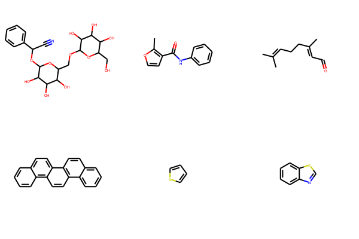

```python
from rdkit import Chem
from rdkit.Chem import Draw
from itertools import islice

molecules = [Chem.MolFromSmiles(smiles)
             for smiles in islice(dataset['smiles'], 6)]

Draw.MolsToGridImage(molecules)
```

That's it for structures right now.

In terms of data, we're interested in measured log(solubility). Let's plot the distribution of experimental data.

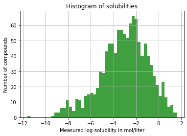

```python
%matplotlib inline
import matplotlib
import numpy as np
import matplotlib.pyplot as plt

solubilities = np.array(dataset["measured log solubility in mols per litre"])
n, bins, patches = plt.hist(solubilities, 50, facecolor='green', alpha=0.75)
plt.xlabel('Measured log-solubility in mol/liter')
plt.ylabel('Number of compounds')
plt.title(r'Histogram of solubilities')
plt.grid(True)
plt.show()
```

## Featurization

Having inspected the data set, we turn to building a predictive model.

We'll need to transform the SMILES in the raw dataset into something that DeepChem can work with. Fingerprints offer a good option. Transformations of this kind are done with a DeepChem [`Featurizer`](https://deepchem.readthedocs.io/en/latest/featurizers.html). A Featurizer transforms input data into a form more appropriate for machine learning.

```python
import deepchem as dc

featurizer = dc.feat.CircularFingerprint(size=1024)
```

As the name implies, [`dc.feat.CircularFingerprint`](https://deepchem.readthedocs.io/en/latest/featurizers.html#circularfingerprint) is a kind of featurizer that transofrms SMILES into [extended connectivity (circular) fingerprints](https://depth-first.com/articles/2019/01/11/extended-connectivity-fingerprints/), computed by RDKit.

Having constructed the `Featurizer`, we rebuild `dataset`, replacing `smiles` with the corresponding fingerprint.

```python
loader = dc.data.CSVLoader(
      tasks=["measured log solubility in mols per litre"], feature_field="smiles",
      featurizer=featurizer)
dataset = loader.create_dataset(dataset_file)
```

## Split

It's common to split a data set into randomized training/validation/testing subsets. The DeepChem authors note that molecular datasets must further account for chemical space. Specifically, subsets of the data should attempt to generate evenly-represented populations of chemical space.

[`ScaffoldSplitter`](https://deepchem.readthedocs.io/en/latest/splitters.html#scaffoldsplitter) uses [Bemis-Murcko scaffolds](https://doi.org/10.1021/jm9602928) to perform the split. At least one other strategy is possible.

```python
splitter = dc.splits.ScaffoldSplitter()
train_dataset, valid_dataset, test_dataset = splitter.train_valid_test_split(
    dataset)
```

The above generates three subsets, available as `train_dataset`, `valid_dataset`, and `test_dataset`. The first few molecules of the training set can be viewed like so:

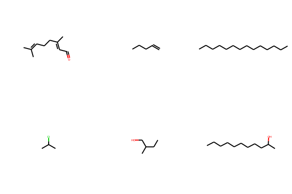

```python
train_mols = [Chem.MolFromSmiles(compound)
              for compound in train_dataset.ids]
Draw.MolsToGridImage(train_mols[:6])
```

And here are the first few molecules of the validation set.

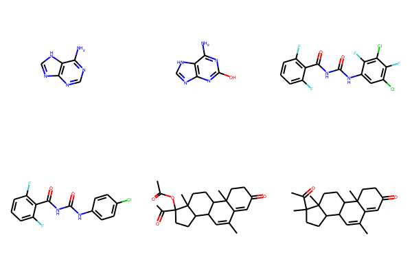

```python
valid_mols = [Chem.MolFromSmiles(compound)
              for compound in valid_dataset.ids]
Draw.MolsToGridImage(valid_mols[:6])
```

One final piece of setup before training can begin training. The DeepChem authors note that performance can be sensitive to input data pre-processing. A common transofmration is to normalize it with a man of zero and unit standard deviation. [`NormalizationTransformer`](https://deepchem.readthedocs.io/en/latest/transformers.html#normalizationtransformer) is one way to do this with DeepChem.

```python
transformers = [
    dc.trans.NormalizationTransformer(transform_y=True, dataset=train_dataset)]

for dataset in [train_dataset, valid_dataset, test_dataset]:
  for transformer in transformers:
      dataset = transformer.transform(dataset)
```

## Train

DeepChem offers many machine learning models to choose from. In this tutorial, we'll use SciKit Learn's [`RandomForestRegressor`](https://scikit-learn.org/stable/modules/generated/sklearn.ensemble.RandomForestRegressor.html). Executing this next cell could take a few seconds.

```python
from sklearn.ensemble import RandomForestRegressor

regressor = RandomForestRegressor(n_estimators=100)
model = dc.models.SklearnModel(regressor)
model.fit(train_dataset)
```

R<sup>2</sup> is a common variance metric. It's available through DeepChem's [`Evaluator`](https://deepchem.readthedocs.io/en/latest/utils.html#evaluation-utils).

```python
from deepchem.utils.evaluate import Evaluator

metric = dc.metrics.Metric(dc.metrics.r2_score)
evaluator = Evaluator(model, valid_dataset, transformers)
r2score = evaluator.compute_model_performance([metric])

print(r2score)
```

```
{'r2_score': 0.1698975513661345}
```

## Optimize

Not so good. Recall that R<sup>2</sup> of one indicates perfect correlation. A better model can be constructed by optimizing hyperparameters. We'll use two:

- `n_estimators`: the number of trees in the forest
- `max_featurres`: the number of features to consider when splitting

Here's a way to set up hyperparameter tuning:

```python
def rf_model_builder(n_estimators, max_features, model_dir):
  sklearn_model = RandomForestRegressor(
      n_estimators=n_estimators, max_features=max_features)
  return dc.models.SklearnModel(sklearn_model, model_dir)
params_dict = {
    "n_estimators": [10, 100],
    "max_features": ["auto", "sqrt", "log2", None],
}

optimizer = dc.hyper.GridHyperparamOpt(rf_model_builder)
best_rf, best_rf_hyperparams, all_rf_results = optimizer.hyperparam_search(
    params_dict, train_dataset, valid_dataset, transformers,
    metric=metric)
```

This routine uses DeepChem's [`GridHyperparamOpt`](https://deepchem.readthedocs.io/en/latest/hyper.html#grid-hyperparameter-optimization). Two other optimizations are available.

We're now ready to try again.

```python
rf_test_evaluator = Evaluator(best_rf, test_dataset, transformers)
rf_test_r2score = rf_test_evaluator.compute_model_performance([metric])
print("RF Test set R^2 %f" % (rf_test_r2score["r2_score"]))
```

```
RF Test set R^2 0.362042
```

Not great, but better.

## Plot

It's often helpful to view a scatterplot of predicted vs. measured values. Here's one way to do that:

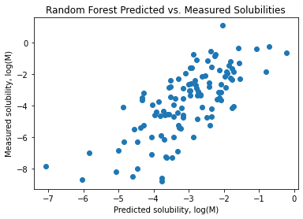

```python
predicted_test = best_rf.predict(test_dataset)
measured_test = test_dataset.y

plt.scatter(predicted_test, measured_test)
plt.xlabel('Predicted solubility, log(M)')
plt.ylabel('Measured solubility, log(M)')
plt.title(r'Random Forest Predicted vs. Measured Solubilities')
plt.show()
```